# A2

Maitri Shah

5/22/2021

```r
library(tidyverse)
```

```r
library(ggplot2)
```

```r
?msleep
```

Question 1- Load the msleep dataset and inspect the dimensions and properties of the data e.g. what type of observations are recorded in the dataset, are any missing, etc. Summarize your findings/understanding about the dataset based on what you have observed.

#Code to demonstrate dimensions and properties and missing data

```r
dim(msleep)
```

```
## [1] 83 11
```

```r
str(msleep)
```

```
## tibble[,11] [83 × 11] (S3: tbl_df/tbl/data.frame)
##  $ name        : chr [1:83] "Cheetah" "Owl monkey" "Mountain beaver" "Greater short-tailed shrew" ...
##  $ genus       : chr [1:83] "Acinonyx" "Aotus" "Aplodontia" "Blarina" ...
##  $ vore        : chr [1:83] "carni" "omni" "herbi" "omni" ...
##  $ order       : chr [1:83] "Carnivora" "Primates" "Rodentia" "Soricomorpha" ...
##  $ conservation: chr [1:83] "lc" NA "nt" "lc" ...
##  $ sleep_total : num [1:83] 12.1 17 14.4 14.9 4 14.4 8.7 7 10.1 3 ...
##  $ sleep_rem   : num [1:83] NA 1.8 2.4 2.3 0.7 2.2 1.4 NA 2.9 NA ...
##  $ sleep_cycle : num [1:83] NA NA NA 0.133 0.667 ...
##  $ awake       : num [1:83] 11.9 7 9.6 9.1 20 9.6 15.3 17 13.9 21 ...
##  $ brainwt     : num [1:83] NA 0.0155 NA 0.00029 0.423 NA NA NA 0.07 0.0982 ...
##  $ bodywt      : num [1:83] 50 0.48 1.35 0.019 600 ...
```

```r
View (is.na (msleep))
```

#The data set msleep records mammals’ sleep data and has data for names of the mammals along with their genus, order, sleep data etc. It has 83 rows and 11 columns. The column names are mostly character (chr) and numeric (num) observations. Missing data is seen by the is.na() command, a value of TRUE suggests missing observation. A few observations in the data set are missing, vore, conservation, sleep_rem, sleep_cycle and brainwt has missing data.

Question 2- Calculate the proportion of each category of vore as a percentage and visualize the results using a bar chart. Comment on the results.

```r
abc <- msleep %>%
count(vore) %>%
mutate(percentage= n/sum(n)*100)
```

#To print abc

```r
abc
```

| vore | n | percentage |
| --- | --- | --- |
| carni | 19 | 22.891566 |
| herbi | 32 | 38.554217 |
| insecti | 5 | 6.024096 |
| omni | 20 | 24.096386 |
| NA | 7 | 8.433735 |

#To visualize using a bar chart

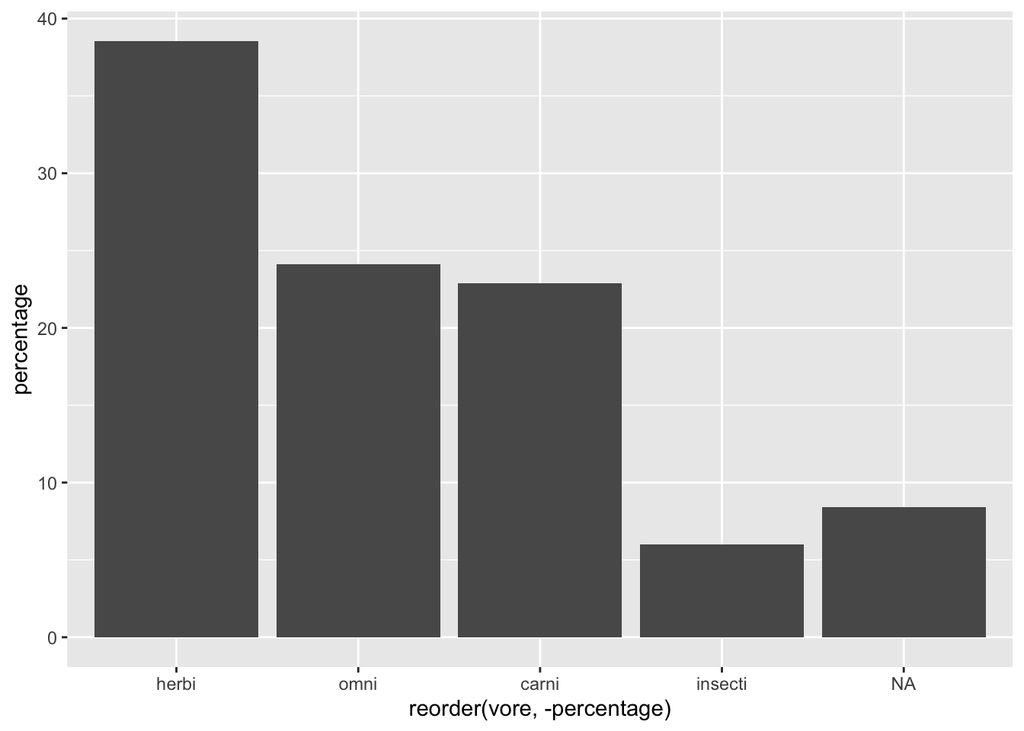

```r
ggplot (abc, aes(x= reorder(vore, -percentage), y= percentage)) +
  geom_bar (stat= "identity")
```

#Comment: The data has total of 83 animals, 7 of whose vores aren’t identified/unknown.There are maximum number of herbivores (32 out of 83) with a proportion about 38.55%. The minimum number excluding the “NA” category is of insectivores (5 out of 83) and a proportion of 6%.

Question 3- Filter the data to extract data for carnivores and herbivore. Hint: vore == ‘herbi’ and vore == ‘carni’. Calculate the mean sleep_total for each group.

#The following code groups by the herbivores and carnivores

```r
msleep %>%
  group_by (vore)%>%
  summarize (mean_sleeptotal= mean(sleep_total, na.rm= TRUE))%>%
  filter (vore == "carni" | vore == "herbi")
```

| vore | mean_sleeptotal |
| --- | --- |
| carni | 10.378947 |
| herbi | 9.509375 |

#Comment: The mean sleep total for carnivores is ~10.38 hours whereas that of the herbivores is ~9.5 hours

Question 4- Create a scatterplot showing the relationship between bodywt and brainwt. Comment on any correlation that is visually apparent. Tip: if you rescale the x and y axis using a logarithmic scale, it may help you to interpret the visualization better e.g. you can append the following to ggplot: scale_x_log10() and scale_y_log10().

#Without tipping

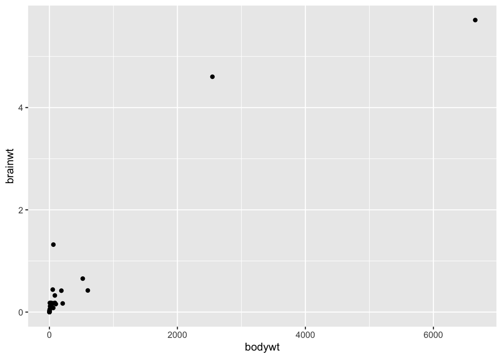

```r
ggplot (data= msleep)+
geom_point (mapping= aes (x=bodywt, y=brainwt, na.rm= TRUE))
```

#With tipping

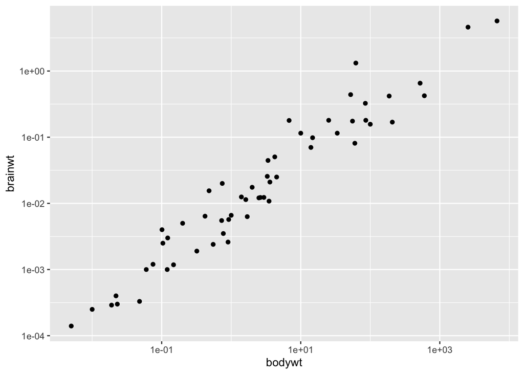

```r
ggplot (data= msleep)+
geom_point (mapping= aes (x=bodywt, y=brainwt, na.rm = TRUE))+
  scale_x_log10()+
  scale_y_log10()
```

#Comment on the co-relation- The scatter plot shows a positive co-relation between brainwt and bodywt, i.e. the increase in one causes an increase in the other variable. Tipping the scale gives a clear visualization. There are more number of observation near (0,0)

Question 5: Calculate the Pearson coefficient of correlation in R, to evaluate the strength of the correlation between bodywt and brainwt. Did the results support your original assumptions from question 4?

```r
cor(x= msleep$bodywt, y= msleep$brainwt, use= "complete.obs", method = "pearson")
```

```
## [1] 0.9337822
```

```r
cor.test(x= msleep$bodywt, y= msleep$brainwt, method = "pearson")
```

```
##
##  Pearson's product-moment correlation
##
## data:  msleep$bodywt and msleep$brainwt
## t = 19.176, df = 54, p-value < 2.2e-16
## alternative hypothesis: true correlation is not equal to 0
## 95 percent confidence interval:
##  0.8891642 0.9608114
## sample estimates:
##       cor
## 0.9337822
```

#Comment: We can see from the results of the cor.test() test that the p value is less than the significance level α=0.05. We can conclude that bodywt and brainwt are significantly correlated with a correlation coefficient of 0.93 that we get from both cor() and cor.test() which is close to one, thereby proving strong co-relation. This supports my original assumptions from Question 4.

Question 6- Determine which mammals are outliers in terms of sleep_total. Outliers, for the sake of this question, are defined as values that are more than 1.5 standard deviations from the mean. Display the name and sleep_total of the mammals which are outliers.

```r
mean_st <-  mean(msleep$sleep_total)
sd_st <-  sd(msleep$sleep_total)
z_score <-  abs((mean_st- msleep$sleep_total)/sd_st)
```

#inspect outliers

```r
msleep %>%
select (name, sleep_total) %>%
filter (z_score > 1.5)
```

| name | sleep_total |
| --- | --- |
| Roe deer | 3.0 |
| Long-nosed armadillo | 17.4 |
| North American Opossum | 18.0 |
| Big brown bat | 19.7 |
| Horse | 2.9 |
| Donkey | 3.1 |
| Giraffe | 1.9 |
| Pilot whale | 2.7 |
| African elephant | 3.3 |
| Thick-tailed opposum | 19.4 |

[output cut: 3 more lines]

#Comment: 13 mammals as shown above are outliers in the data